# R Graphics Showcase — from Statistical Basics to Showpiece Visualisations

Statistics — Bachelor, Year 2

# 1 How to use this showcase

This document is a **visual catalogue for a statistics course**. It is deliberately broader than a conventional introduction to `ggplot2`: the first sections cover statistical graphics that students should be able to read and construct routinely; later sections show more specialised displays for uncertainty, multivariate structure, flows, hierarchies, repeated measurements, spatial data and interactive exploration.

The aim is not to encourage students to use the most spectacular graphic available. The guiding question is always:

> **What comparison should the reader be able to make?**

A sophisticated graphic is useful only when its visual structure matches the statistical structure of the problem.

Most examples use datasets distributed with R or `ggplot2`. A few advanced examples require optional packages. The document checks whether these packages are installed before evaluating those examples, so the rest of the file can still knit.

## 1.1 Optional packages

The following packages extend the showcase.

```r
install.packages(c(
  "hexbin",
  "ggbeeswarm",
  "ggridges",
  "ggdist",
  "GGally",
  "treemapify",
  "ggalluvial",
  "circlize",
  "plotly",
  "maps"
))
```

# 2 Visualization as statistical reasoning

A visualization can play several roles in an analysis. It may be used to discover structure, diagnose a model, compare groups, communicate an estimate, reveal uncertainty, or guide a reader toward a particular comparison.

This is why plotting is not simply the final decorative stage of an analysis. A plot can change the statistical question itself.

## 2.1 Exploratory and explanatory graphics

An **exploratory graphic** is mainly for the analyst. We may try several scales, groupings, transformations and views because the purpose is discovery.

An **explanatory graphic** is designed for an audience. The analyst has already identified an important pattern or comparison and uses visual hierarchy, annotation and simplification to help the reader see it.

A useful summary is:

> **Explore broadly; explain selectively.**

# 3 A short guide to graphical perception

Not all visual encodings are equally easy to decode. Comparisons based on **position along a common scale** are generally more precise than comparisons based on angle, area, volume or colour intensity.

This has practical consequences:

- bars and dot plots are often easier to compare than pie slices;
- aligned confidence intervals are easier to compare than differently sized circles;
- colour is excellent for grouping and highlighting, but usually poor for communicating small quantitative differences;
- a visually impressive chart can still be statistically inefficient.

The advanced circular and flow graphics later in this document should therefore be viewed as **special-purpose tools**, not automatic replacements for simpler charts.

## 3.1 Colour, hierarchy and accessibility

Colour can establish hierarchy, encode groups and direct attention. Good practice includes:

- use qualitative palettes for unordered categories;
- use sequential palettes for ordered magnitudes;
- use diverging palettes when values meaningfully depart from a reference point;
- avoid relying on red versus green alone;
- use labels, position, shape or line type when redundant encoding improves accessibility.

Viridis scales are useful because they are perceptually well behaved and remain interpretable under many forms of colour-vision deficiency.

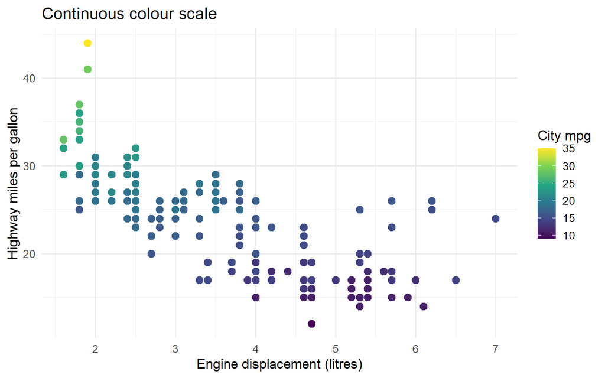

```r
ggplot(mpg, aes(displ, hwy, colour = cty)) +
  geom_point(size = 3) +
  scale_colour_viridis_c() +
  labs(
    title = "Continuous colour scale",
    x = "Engine displacement (litres)",
    y = "Highway miles per gallon",
    colour = "City mpg"
  )
```

# 4 The grammar of graphics

A `ggplot2` graphic can be thought of as a composition of:

1. **data**;
2. **aesthetic mappings**;
3. **geometries**;
4. **statistical transformations**;
5. **scales**;
6. **coordinate systems**;
7. **facets**;
8. **annotations and theme elements**.

The same dataset can therefore produce very different representations simply by changing the geometry, statistical transformation or coordinate system.

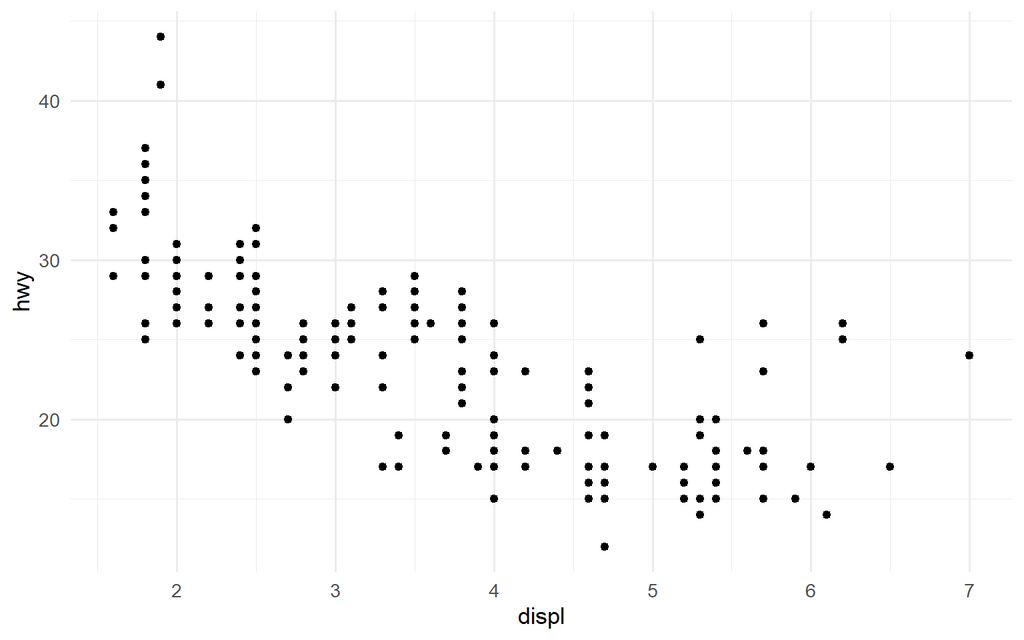

```r
ggplot(mpg, aes(displ, hwy)) +
  geom_point()
```

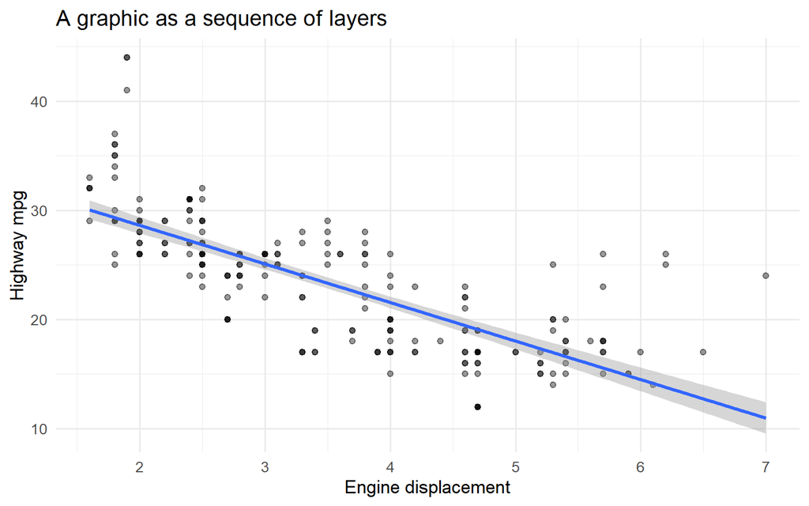

```r
ggplot(mpg, aes(displ, hwy)) +
  geom_point(alpha = 0.4) +
  geom_smooth(method = "lm") +
  labs(
    title = "A graphic as a sequence of layers",
    x = "Engine displacement",
    y = "Highway mpg"
  )
```

# 5 Categorical data

## 5.1 Bar chart

A bar chart represents counts or pre-computed quantities using length. Because all bars share a common baseline, comparisons are usually accurate and rapid.

Use it when the main question concerns **how frequent categories are** or **how a quantity differs across categories**.

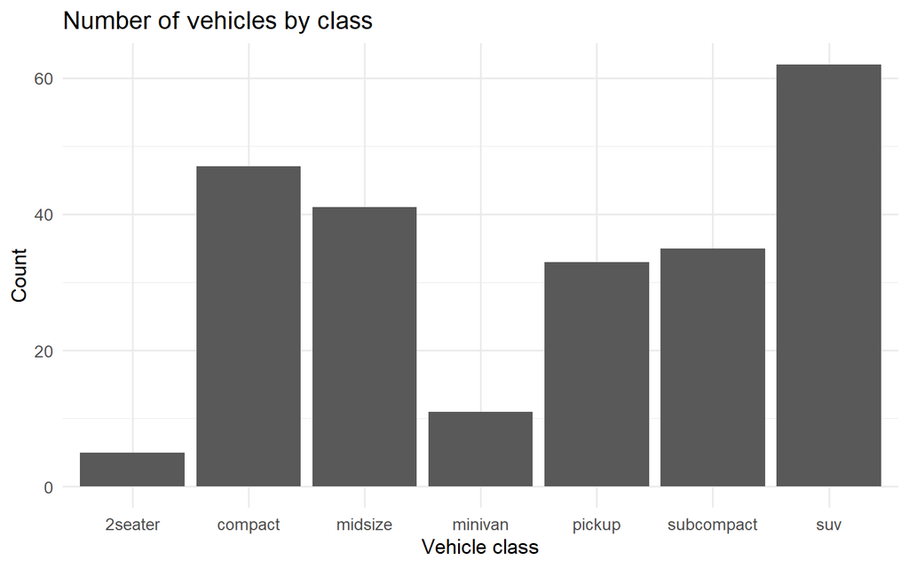

```r
ggplot(mpg, aes(class)) +
  geom_bar() +
  labs(
    title = "Number of vehicles by class",
    x = "Vehicle class",
    y = "Count"
  )
```

## 5.2 Ordered bar chart

Ordering categories by frequency often reveals structure that alphabetical order hides.

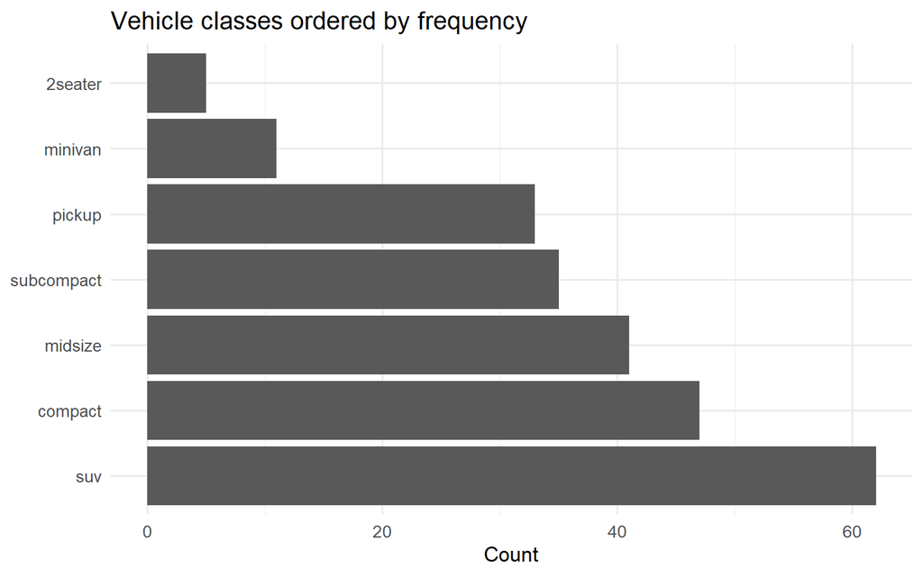

```r
ggplot(mpg, aes(fct_infreq(class))) +
  geom_bar() +
  coord_flip() +
  labs(
    title = "Vehicle classes ordered by frequency",
    x = NULL,
    y = "Count"
  )
```

## 5.3 Grouped bar chart

Grouped bars support direct comparisons between subgroups within each category. They become difficult to read when either dimension has many levels.

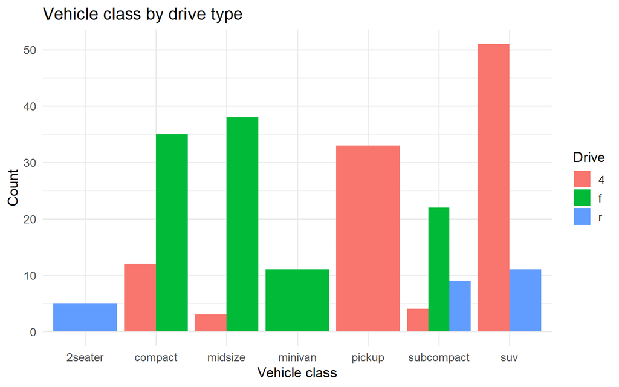

```r
ggplot(mpg, aes(class, fill = drv)) +
  geom_bar(position = "dodge") +
  labs(
    title = "Vehicle class by drive type",
    x = "Vehicle class",
    y = "Count",
    fill = "Drive"
  )
```

Is there anything awkward here? What about this one?

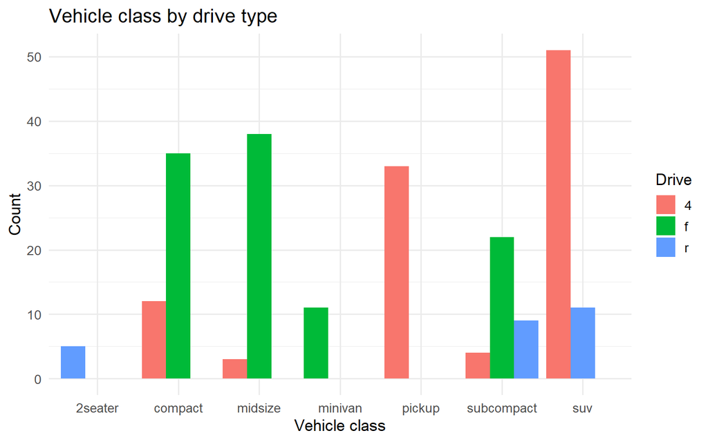

```r
ggplot(mpg, aes(class, fill = drv)) +
  geom_bar(position = position_dodge(preserve = "single")) +
  labs(
    title = "Vehicle class by drive type",
    x = "Vehicle class",
    y = "Count",
    fill = "Drive"
  )
```

## 5.4 Proportional stacked bars

`position = "fill"` converts counts into within-category proportions. This is useful for comparing **composition**, but absolute sample sizes disappear.

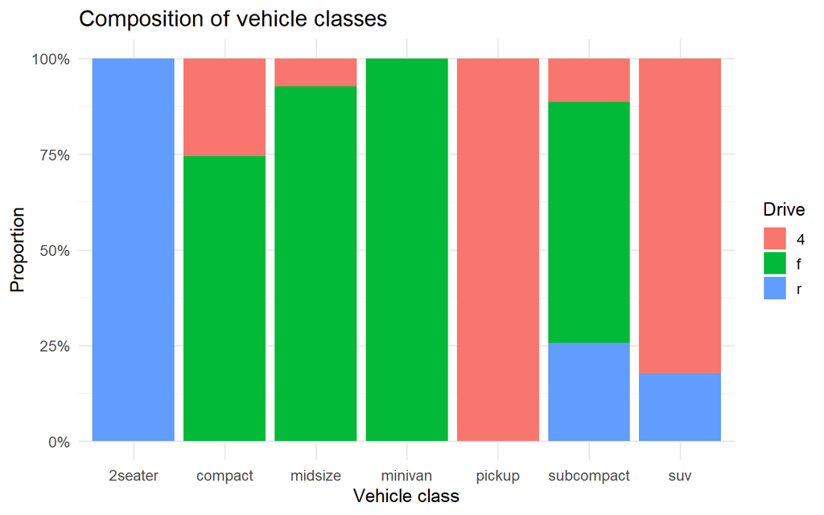

```r
ggplot(mpg, aes(class, fill = drv)) +
  geom_bar(position = "fill") +
  scale_y_continuous(labels = percent) +
  labs(
    title = "Composition of vehicle classes",
    x = "Vehicle class",
    y = "Proportion",
    fill = "Drive"
  )
```

## 5.5 Mosaic plot

A mosaic plot represents a contingency table using rectangle areas. It is useful when both variables are categorical and the goal is to inspect dependence.

Because area is less precisely decoded than aligned position, proportional bar charts may be preferable when exact comparisons matter.

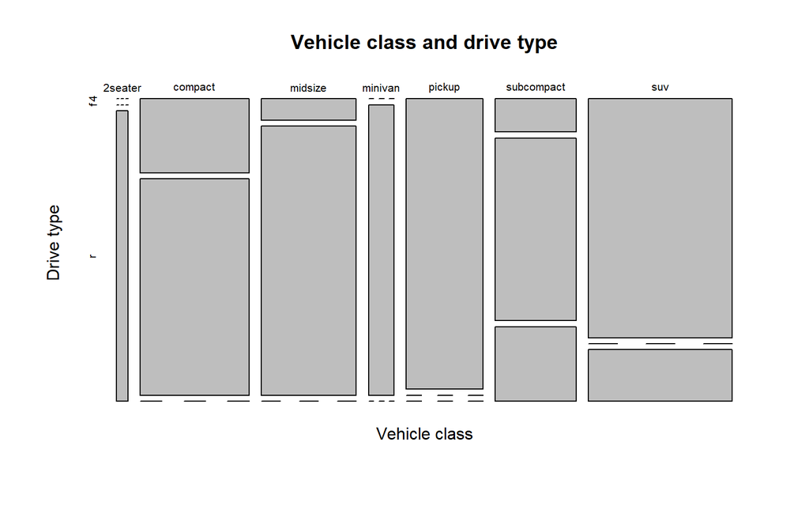

```r
mosaicplot(
  table(mpg$class, mpg$drv),
  main = "Vehicle class and drive type",
  xlab = "Vehicle class",
  ylab = "Drive type"
)
```

# 6 Univariate quantitative distributions

## 6.1 Histogram

A histogram groups values into intervals. The bin width is therefore part of the statistical representation.

Always inspect more than one sensible bin width before making claims about modes, gaps or skewness.

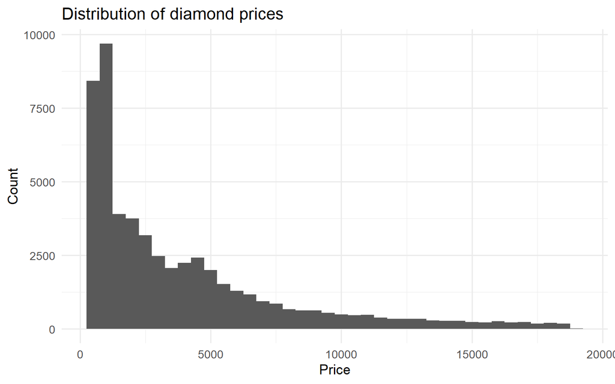

```r
ggplot(diamonds, aes(price)) +
  geom_histogram(binwidth = 500) +
  labs(
    title = "Distribution of diamond prices",
    x = "Price",
    y = "Count"
  )
```

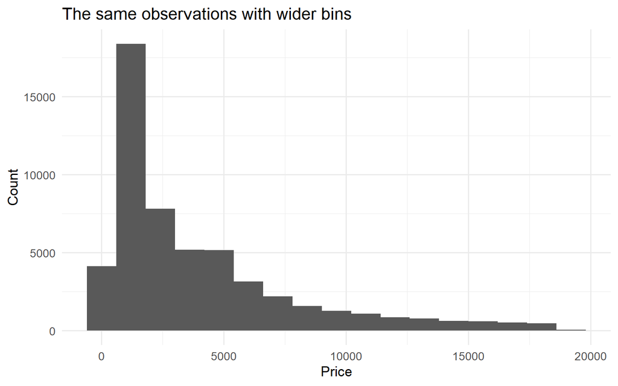

```r
ggplot(diamonds, aes(price)) +
  geom_histogram(binwidth = 1200) +
  labs(
    title = "The same observations with wider bins",
    x = "Price",
    y = "Count"
  )
```

## 6.2 Density plot

A kernel density estimate replaces bins with a smooth curve. Its bandwidth controls the trade-off between local detail and smoothing.

A density curve is an **estimate of distributional shape**, not the raw data themselves.

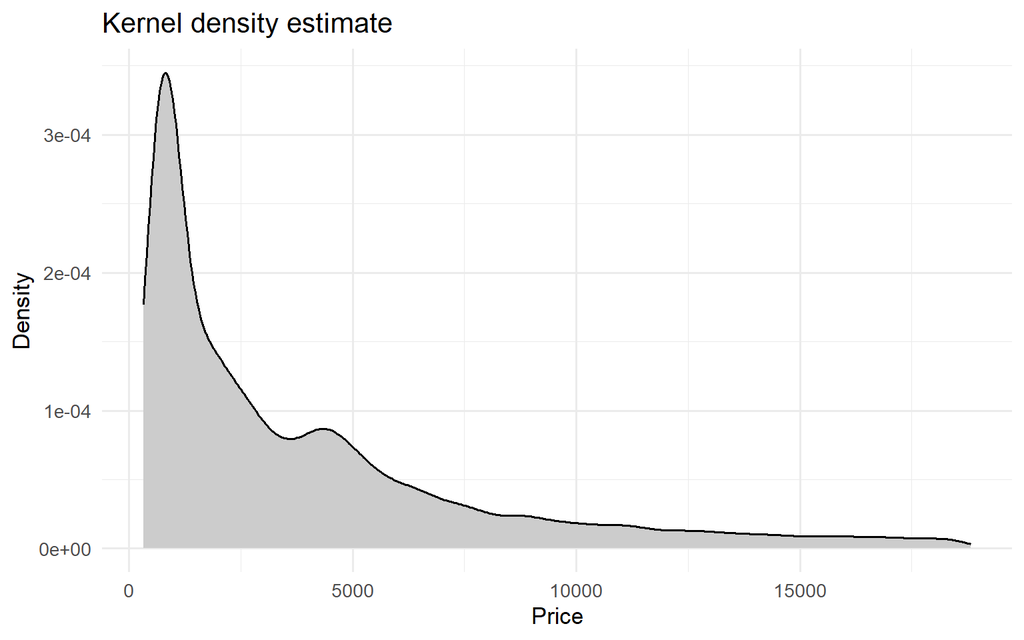

```r
ggplot(diamonds, aes(price)) +
  geom_density(fill = "grey80") +
  labs(
    title = "Kernel density estimate",
    x = "Price",
    y = "Density"
  )
```

## 6.3 Empirical cumulative distribution function

The ECDF shows the proportion of observations less than or equal to each value. Unlike histograms and density estimates, it requires no bin-width or bandwidth choice.

It is particularly useful when quantiles and stochastic ordering matter.

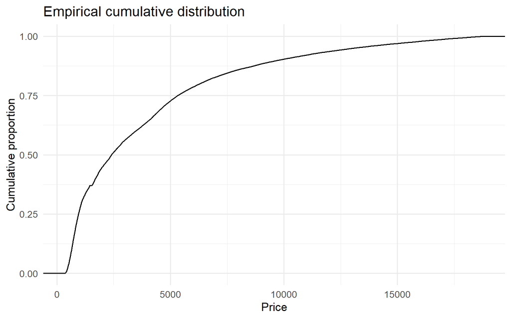

```r
ggplot(diamonds, aes(price)) +
  stat_ecdf() +
  labs(
    title = "Empirical cumulative distribution",
    x = "Price",
    y = "Cumulative proportion"
  )
```

## 6.4 Boxplot

A boxplot compresses a distribution into quartiles, median, whiskers and potential outliers.

It is excellent for compact comparisons across groups, but can conceal multimodality and sample size.

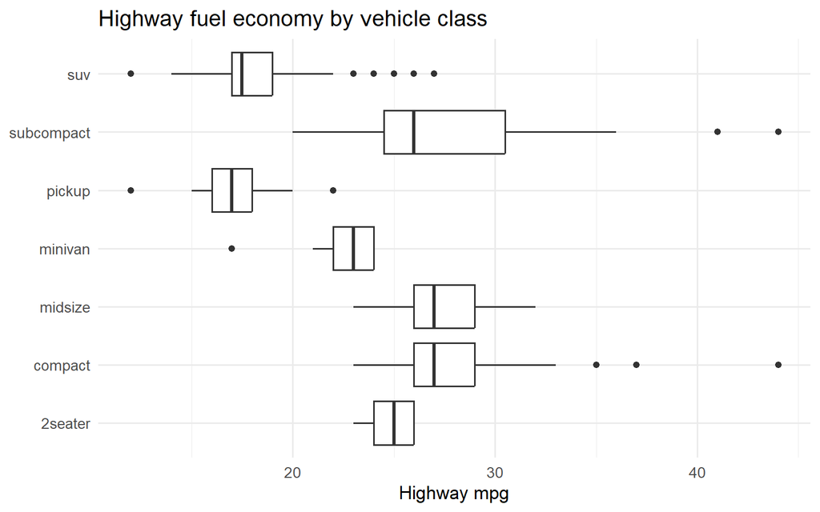

```r
ggplot(mpg, aes(class, hwy)) +
  geom_boxplot() +
  coord_flip() +
  labs(
    title = "Highway fuel economy by vehicle class",
    x = NULL,
    y = "Highway mpg"
  )
```

## 6.5 Boxplot plus observations

Adding jittered observations restores information about sample size and local structure.

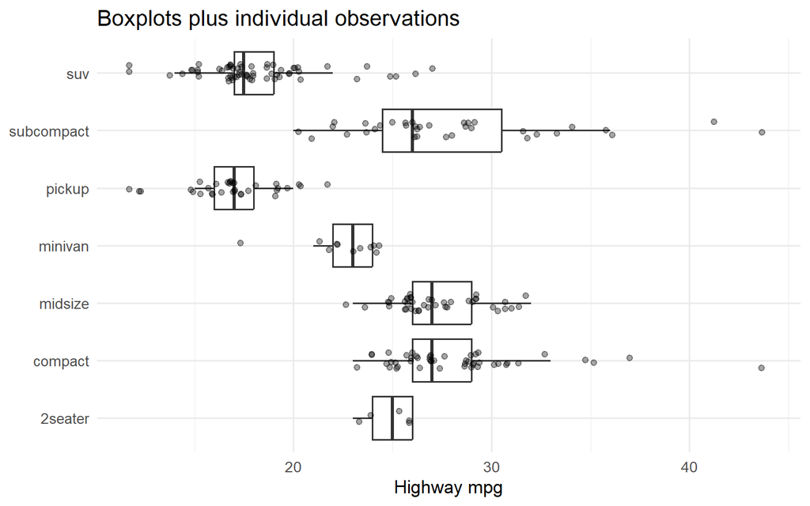

```r
ggplot(mpg, aes(class, hwy)) +
  geom_boxplot(outlier.shape = NA) +
  geom_jitter(width = 0.15, alpha = 0.35) +
  coord_flip() +
  labs(
    title = "Boxplots plus individual observations",
    x = NULL,
    y = "Highway mpg"
  )
```

## 6.6 Violin plot

A violin plot mirrors a density estimate around a central axis. It communicates distributional shape more directly than a boxplot, but its appearance depends on smoothing.

Combining a violin with a boxplot gives both shape and familiar summary statistics.

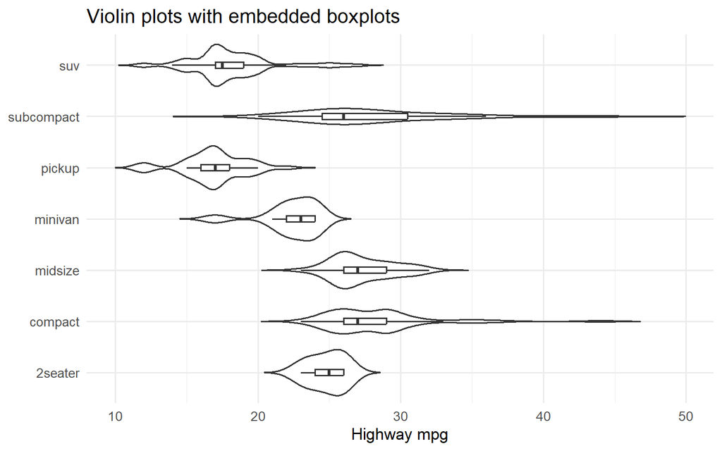

```r
ggplot(mpg, aes(class, hwy)) +
  geom_violin(trim = FALSE) +
  geom_boxplot(width = 0.12, outlier.shape = NA) +
  coord_flip() +
  labs(
    title = "Violin plots with embedded boxplots",
    x = NULL,
    y = "Highway mpg"
  )
```

## 6.7 Beeswarm / quasirandom plot

A beeswarm-like display keeps individual observations visible while reducing overlap. It is especially useful for small or medium-sized samples.

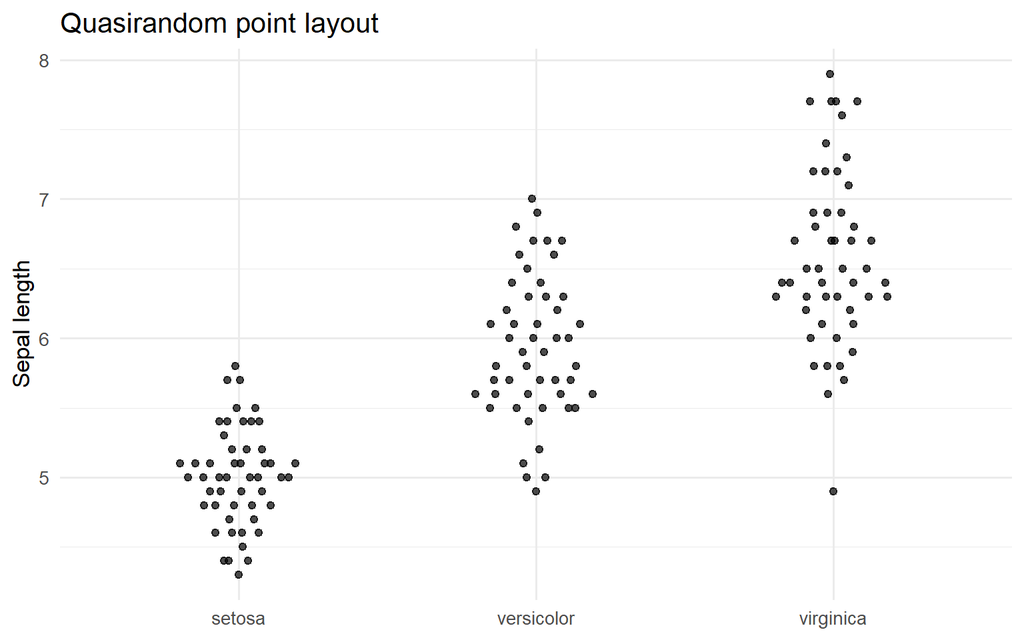

```r
if (has_pkg("ggbeeswarm")) {
  ggplot(iris, aes(Species, Sepal.Length)) +
    ggbeeswarm::geom_quasirandom(width = 0.22, alpha = 0.7) +
    labs(
      title = "Quasirandom point layout",
      x = NULL,
      y = "Sepal length"
    )
}
```

## 6.8 Ridgeline plot

Ridgeline plots stack density curves vertically. They work well for comparing many related distributions, especially when the ordering of groups has substantive meaning.

Avoid them when precise vertical comparison of densities is required.

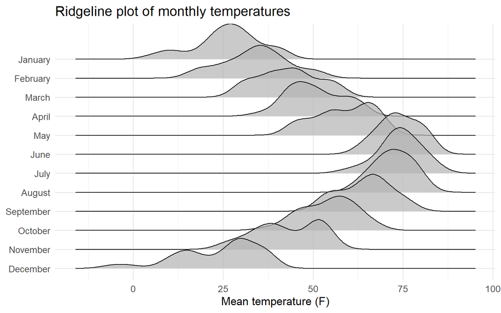

```r
if (has_pkg("ggridges")) {
  ggplot(
    ggridges::lincoln_weather,
    aes(x = `Mean Temperature [F]`, y = Month)
  ) +
    ggridges::geom_density_ridges(
      scale = 2.4,
      alpha = 0.7
    ) +
    labs(
      title = "Ridgeline plot of monthly temperatures",
      x = "Mean temperature (F)",
      y = NULL
    )
}
```

## 6.9 Raincloud-style plot

Raincloud plots combine distribution shape, uncertainty/summary and raw observations. They are useful when you want to avoid choosing between a violin plot, boxplot and dot plot.

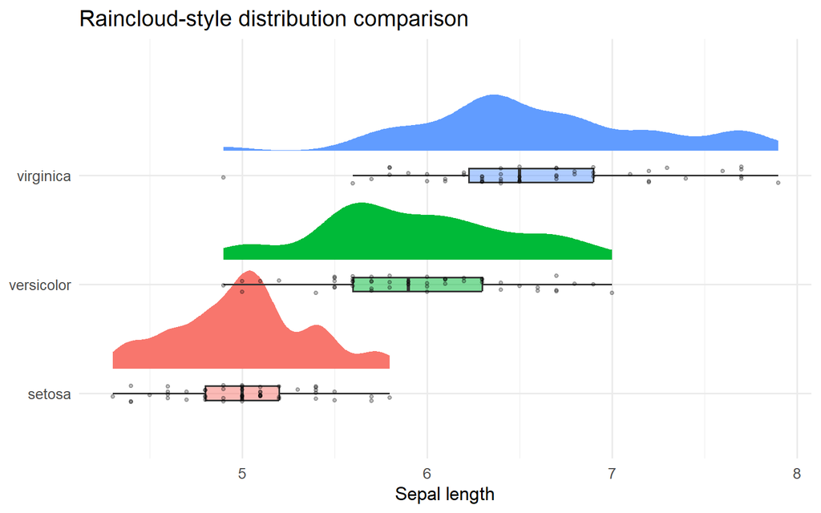

```r
if (has_pkg("ggdist")) {
  ggplot(
    iris,
    aes(x = Sepal.Length, y = Species, fill = Species)
  ) +
    ggdist::stat_halfeye(
      adjust = 0.6,
      width = 0.6,
      .width = 0,
      justification = -0.25,
      point_colour = NA
    ) +
    geom_boxplot(
      width = 0.13,
      outlier.shape = NA,
      alpha = 0.5
    ) +
    geom_jitter(
      height = 0.08,
      width = 0,
      alpha = 0.25,
      size = 1
    ) +
    guides(fill = "none") +
    labs(
      title = "Raincloud-style distribution comparison",
      x = "Sepal length",
      y = NULL
    )
}
```

# 7 Relationships between quantitative variables

## 7.1 Scatter plot

The scatter plot is the default display for two quantitative variables because it preserves individual observations and uses position on common scales.

Look for direction, strength, nonlinearity, clusters, gaps and influential observations.

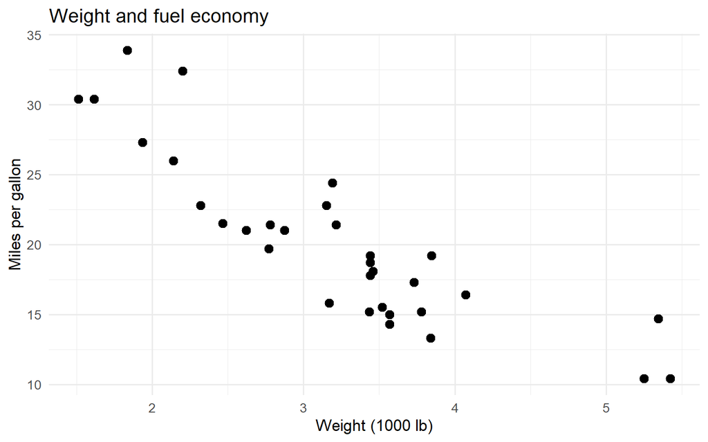

```r
ggplot(cars, aes(wt, mpg)) +
  geom_point(size = 3) +
  labs(
    title = "Weight and fuel economy",
    x = "Weight (1000 lb)",
    y = "Miles per gallon"
  )
```

## 7.2 Linear trend and confidence band

A fitted line summarizes an assumed linear relationship. The confidence band describes uncertainty about the estimated mean relationship, not the range of future observations.

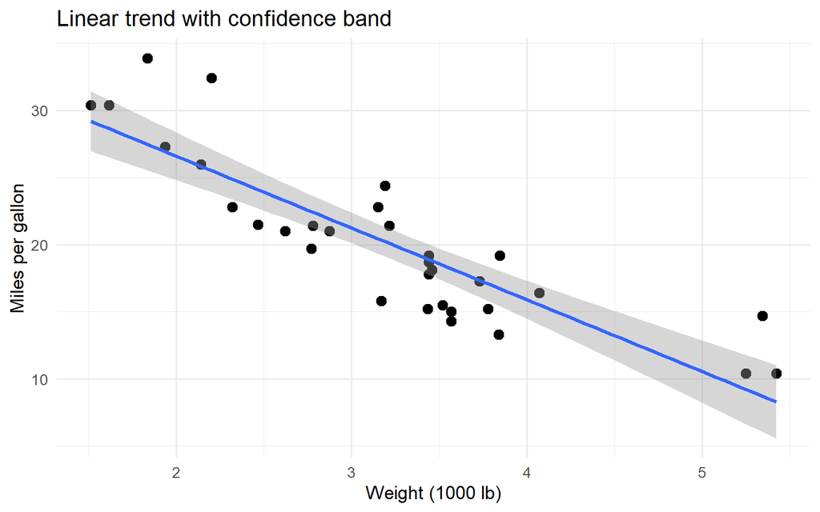

```r
ggplot(cars, aes(wt, mpg)) +
  geom_point(size = 3) +
  geom_smooth(method = "lm") +
  labs(
    title = "Linear trend with confidence band",
    x = "Weight (1000 lb)",
    y = "Miles per gallon"
  )
```

## 7.3 Non-parametric smoother

A smoother is useful during exploration because it can reveal nonlinear structure without forcing a straight line.

Its shape depends on smoothing parameters, so it should not be treated as an unquestionable representation of the underlying process.

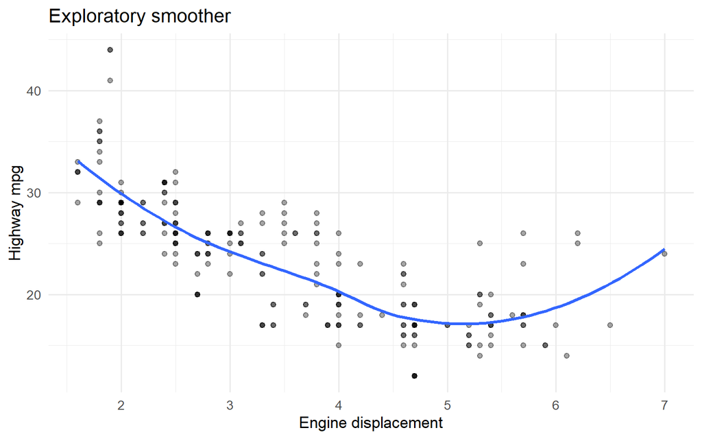

```r
ggplot(mpg, aes(displ, hwy)) +
  geom_point(alpha = 0.35) +
  geom_smooth(se = FALSE) +
  labs(
    title = "Exploratory smoother",
    x = "Engine displacement",
    y = "Highway mpg"
  )
```

## 7.4 Colour, size and shape

Additional aesthetics can encode more variables, but each extra encoding increases cognitive load.

Use colour for grouping, shape for a small number of categories, and size only when approximate magnitude comparisons are sufficient.

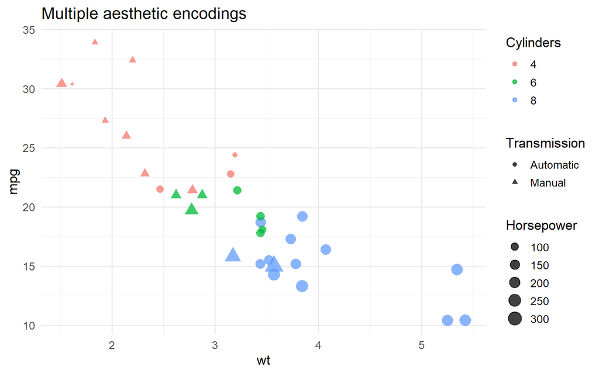

```r
ggplot(cars, aes(wt, mpg, colour = cyl, shape = am, size = hp)) +
  geom_point(alpha = 0.75) +
  labs(
    title = "Multiple aesthetic encodings",
    colour = "Cylinders",
    shape = "Transmission",
    size = "Horsepower"
  )
```

## 7.5 Faceting

Small multiples repeat the same simple graphic across subgroups. They are often clearer than trying to encode every group with colour or shape in one panel.

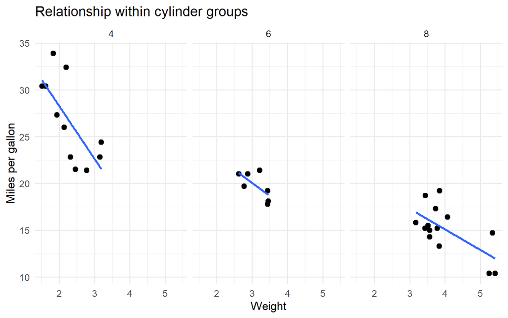

```r
ggplot(cars, aes(wt, mpg)) +
  geom_point(size = 2.5) +
  geom_smooth(method = "lm", se = FALSE) +
  facet_wrap(~ cyl) +
  labs(
    title = "Relationship within cylinder groups",
    x = "Weight",
    y = "Miles per gallon"
  )
```

# 8 Dense relationships and overplotting

## 8.1 Transparency

Transparency lets repeated or nearby observations build visual density.

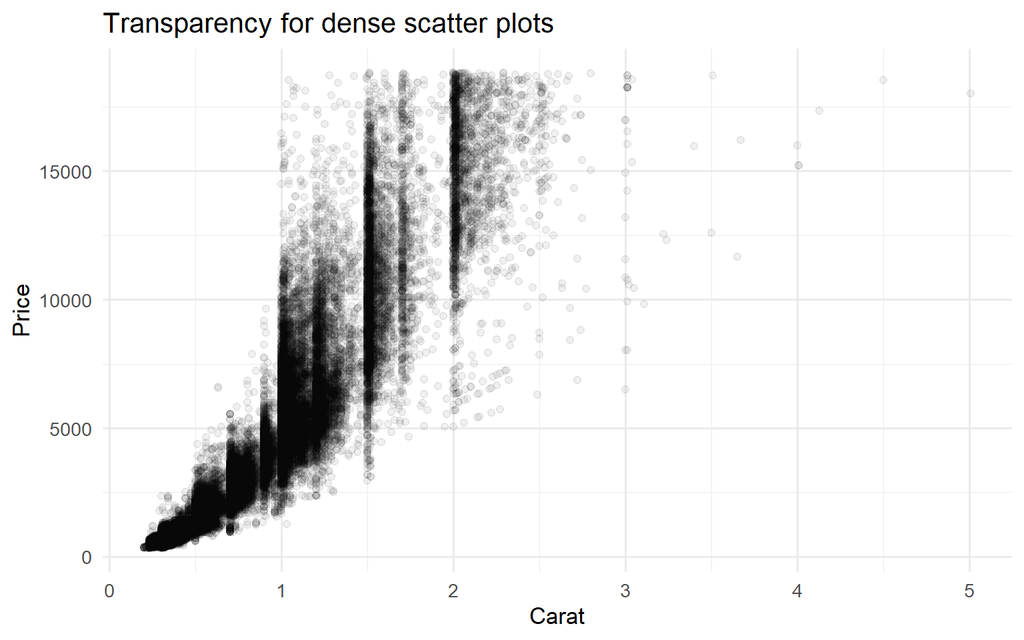

```r
ggplot(diamonds, aes(carat, price)) +
  geom_point(alpha = 0.06) +
  labs(
    title = "Transparency for dense scatter plots",
    x = "Carat",
    y = "Price"
  )
```

## 8.2 Two-dimensional bins

Instead of drawing every point, `geom_bin_2d()` counts observations inside rectangular cells.

This changes the question from “where is each observation?” to “where is the mass of the data?”

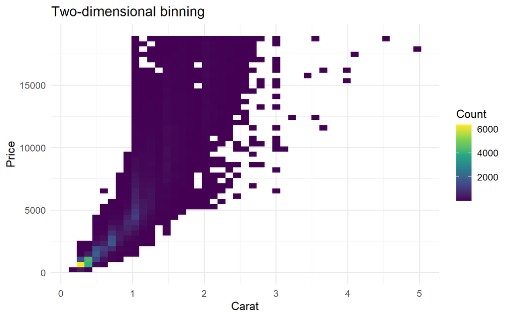

```r
ggplot(diamonds, aes(carat, price)) +
  geom_bin_2d(bins = 45) +
  scale_fill_viridis_c() +
  labs(
    title = "Two-dimensional binning",
    x = "Carat",
    y = "Price",
    fill = "Count"
  )
```

## 8.3 Hexagonal binning

Hexagons reduce some directional artefacts of rectangular grids and are popular for very large scatter plots.

```r
if (has_pkg("hexbin")) {
  ggplot(diamonds, aes(carat, price)) +
    geom_hex(bins = 45) +
    scale_fill_viridis_c() +
    labs(
      title = "Hexagonal binning",
      x = "Carat",
      y = "Price",
      fill = "Count"
    )
}
```

[output not shown]

## 8.4 Two-dimensional density contours

Contours summarize regions of similar estimated density. They are useful for seeing clusters and shape in dense bivariate data.

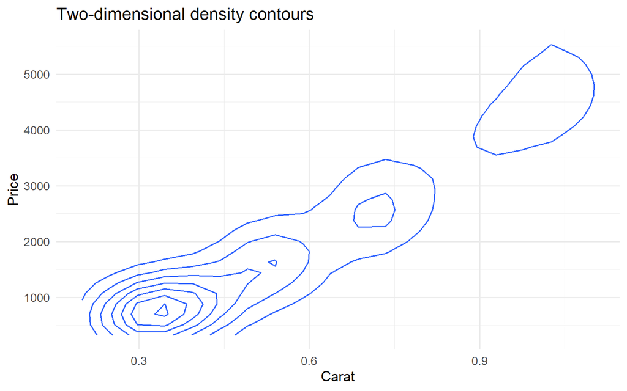

```r
ggplot(diamonds, aes(carat, price)) +
  geom_density_2d() +
  labs(
    title = "Two-dimensional density contours",
    x = "Carat",
    y = "Price"
  )
```

# 9 Time series and ordered data

## 9.1 Line chart

Connecting observations with lines is appropriate when the horizontal dimension is ordered and continuity is meaningful.

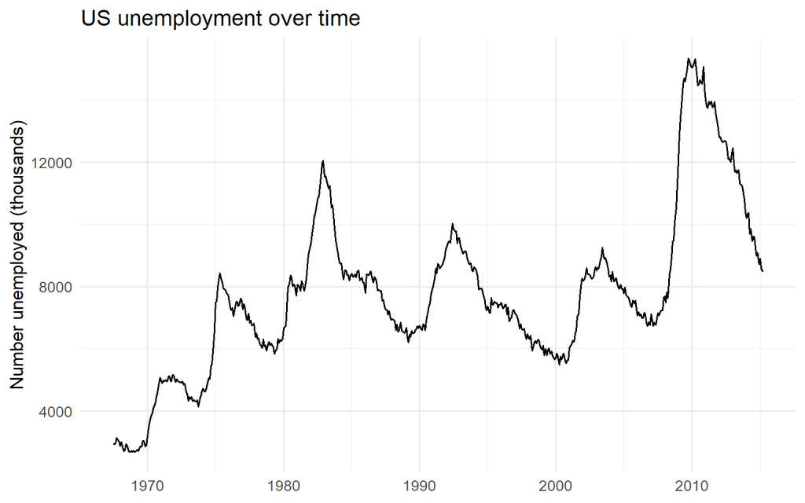

```r
ggplot(economics, aes(date, unemploy)) +
  geom_line() +
  labs(
    title = "US unemployment over time",
    x = NULL,
    y = "Number unemployed (thousands)"
  )
```

## 9.2 Area chart

An area chart emphasizes accumulated magnitude relative to a baseline. It is visually stronger than a line chart, which can be useful when magnitude is central but distracting when trend is the main message.

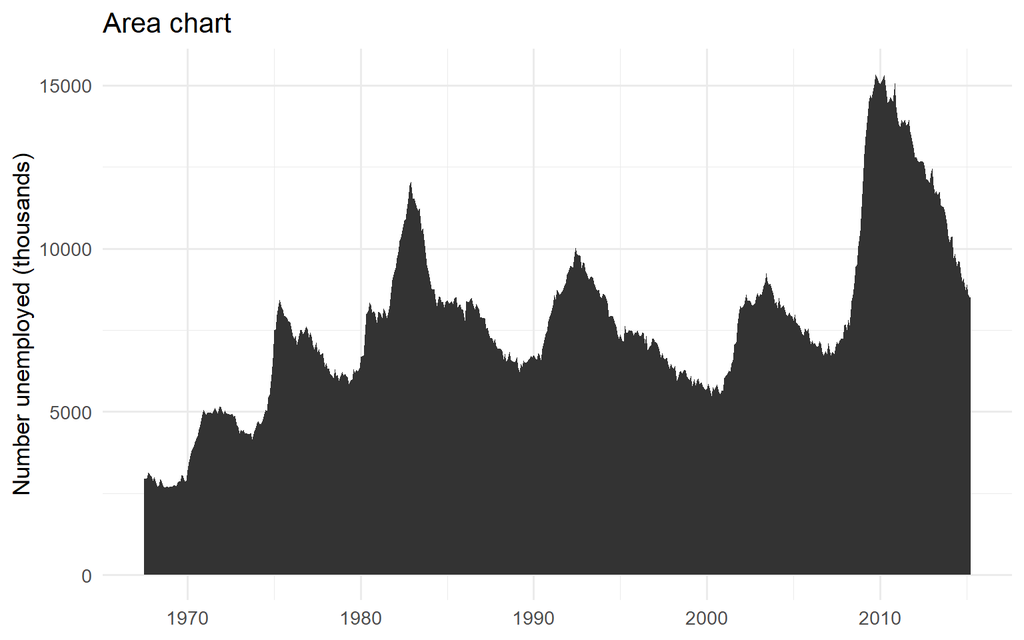

```r
ggplot(economics, aes(date, unemploy)) +
  geom_area() +
  labs(
    title = "Area chart",
    x = NULL,
    y = "Number unemployed (thousands)"
  )
```

## 9.3 Step chart

A step chart is appropriate when values remain constant until a discrete change occurs.

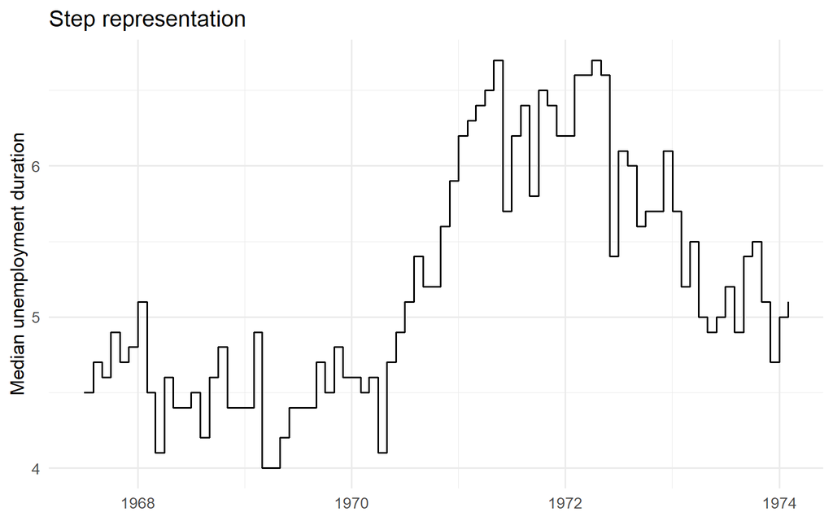

```r
ggplot(head(economics, 80), aes(date, uempmed)) +
  geom_step() +
  labs(
    title = "Step representation",
    x = NULL,
    y = "Median unemployment duration"
  )
```

## 9.4 Bump chart

Bump charts show how ranks change over time. They are useful when **relative position** matters more than the raw quantity.

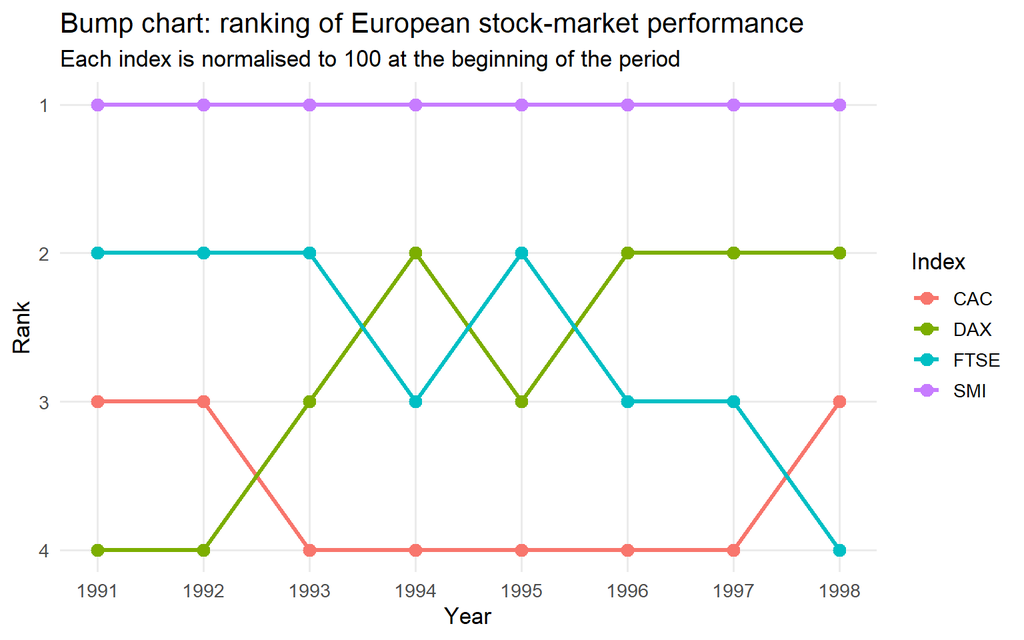

```r
# EuStockMarkets is included with R.
# We convert each index to performance relative to its initial value.

stock_data <- EuStockMarkets |>
  as.data.frame() |>
  mutate(
    time = time(EuStockMarkets),
    year = floor(time)
  ) |>
  as_tibble() |>
  pivot_longer(
    cols = c(DAX, SMI, CAC, FTSE),
    names_to = "index",
    values_to = "value"
  ) |>
  group_by(index) |>
  mutate(
    performance = 100 * value / first(value)
  ) |>
  ungroup()

# Use the last available observation of each year
stock_rank <- stock_data |>
  group_by(year, index) |>
  slice_max(time, n = 1, with_ties = FALSE) |>
  ungroup() |>
  group_by(year) |>
  mutate(
    rank = rank(-performance, ties.method = "first")
  ) |>
  ungroup()

ggplot(
  stock_rank,
  aes(
    x = year,
    y = rank,
    group = index,
    colour = index
  )
) +
  geom_line(linewidth = 1.2) +
  geom_point(size = 3) +
  scale_y_reverse(
    breaks = 1:4
  ) +
  scale_x_continuous(
    breaks = sort(unique(stock_rank$year))
  ) +
  labs(
    title = "Bump chart: ranking of European stock-market performance",
    subtitle = "Each index is normalised to 100 at the beginning of the period",
    x = "Year",
    y = "Rank",
    colour = "Index"
  ) +
  theme(
    panel.grid.minor = element_blank()
  )
```